# DA2 - Assignment 1 - COVID-19 Analysis

Dominik Gulacsy

28/11/2020

# Aim of Analysis

The goal of this analysis is to look at what kind of patterns of association can be discovered between COVID-19 deaths and confirmed cases. One possible final objective of such analysis is to evaluate the healthcare system of different countries to a certain extent. However, this interpretation of model results should be considered with carefulness and limitations has to be made. This is partly because in the analysis only one particular aspect of the situation is taken into account, deaths compared to confirmed cases. Furthermore, results are not controlled for many other variables that may also affect a country’s numbers (e.g.: demographic structure and sociological dynamics) AKA confounders.

# Variable description and Data Quality Assessment

My variables of focus in this analysis are deaths per capita and confirmed cases per capita for each country it is available. All COVID-19 data is from administrative sources and reported by the countries themselves. The process of data gathering may differ from countries to countries and even within the country. For example, in larger countries like India the process may be different in different counties/municipalities. In case of this dataset, we may have multiple interpretations of how the population can be defined. One possibility is to consider the population as all COVID-19 infection cases that occurred until 21th Sept 2020. Therefore the gathered data represents only the part of the population which was effectively observed (mainly by testing). An other way to look at it is to say that the population is the infinite number of possible outcomes of COVID-19 infections and consequences and this data only shows one realization of such random variable. One of the issues regarding data quality is that there are some countries where the numbers reported may be influenced due to political reasons. So these countries’ numbers may be significantly lower than actually they are. Secondly, reliability is also questionable. It is hard to believe that if cases were recounted they would be the same for the same observations. Most likely the data contains many errors due to duplication, mishandling and so on. The third issue is comparability. Since there is no universal testing procedure in a global sense some countries might have higher or lower numbers solely due to their testing practices. Population data is gathered through reports of countries that the World Bank acknowledges. Due to this, it is likely that the data contains measurement error and might contain some politics-driven biases.

## Exploratory Data Analysis

# Drop irrelevent observations

In case of those countries that have very low confirmed cases, numbers do not really reflect their capability to combat the virus. To have countries where there is at least some information on their performance I dropped countries with lower than 100 confirmed cases to only include more exposed countries in the analysis. Death per capita and confirmed cases per capita are rather small numbers so I scaled the variables to show deaths and confirmed cases per 100K persons. This way they are more interpretable.

```r
# Drop countries with very low confirmed cases
df <- df[which(df$confirmed>100),]

# Get Y & X variables (Number of registered death per capita & Number of registered case per capita)
df$death_pc <- df$death/df$population
df$confirmed_pc <- df$confirmed/df$population

# Scaling variables
# Update Y & X variables to show as "per 100K persons"
df$death_p100Kp <- 100000*df$death/df$population
df$confirmed_p100Kp <- 100000*df$confirmed/df$population
```

# Summary Statistics

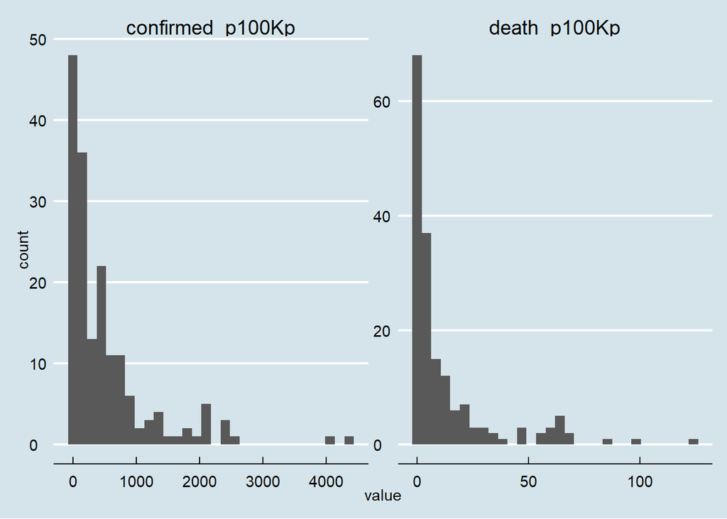

```r
# Histograms of Y & X variables
df[,c("confirmed_p100Kp","death_p100Kp")] %>%
  keep(is.numeric) %>%
  gather() %>%
  ggplot(aes(value)) +
  facet_wrap(~key, scales = "free") +
  geom_histogram()+
  theme_economist() +
  scale_fill_economist()
```

```r
# Summary statistics
summary <- summary(df[,c("death_p100Kp","confirmed_p100Kp")])
kable(summary)
```

|  | death_p100Kp | confirmed_p100Kp |
| --- | --- | --- |
|  | Min. : 0.0000 | Min. : 0.878 |
|  | 1st Qu.: 0.9725 | 1st Qu.: 62.749 |
|  | Median : 4.5040 | Median : 239.845 |
|  | Mean : 12.8750 | Mean : 515.034 |
|  | 3rd Qu.: 13.7129 | 3rd Qu.: 671.164 |
|  | Max. :124.0402 | Max. :4364.445 |

# Variable Transformation (Taking logs)

Substantial: Level changes in both deaths and confirmed cases are hard to interpret, however it can be resolved by taking the logarithm of the variables. Percentage differences make more sense. Statistical: As it could be seen on the histograms of variables they have distribution similar to lognormal. Therefore taking the logarithm of these variables would result in distribution that are approximately normal. This is favorable characteristic in statistics. It provides much better approximation since it makes the association close to linear. In other cases the degree of non-linearity is very high. For these reasons I decided to take the ln of variables. In order to this I dropped those observations where the number of deaths is 0.

# Running models

To find out which model specification is the best I ran the following 4 regression models: 1. Simple linear regression 2. Quadratic (linear) regression 3. Piecewise linear spline regression 4. Weighted linear regression, using population as weights

Results were the following:

```
##                      Estimate Std. Error   t value     Pr(>|t|)   CI Lower
## (Intercept)         -3.648375 0.25049169 -14.56486 2.593993e-31 -4.1430022
## ln_confirmed_p100Kp  0.945219 0.04732776  19.97177 1.165151e-45  0.8517645
##                      CI Upper  DF
## (Intercept)         -3.153748 163
## ln_confirmed_p100Kp  1.038674 163
```

```
##
## Call:
## lm_robust(formula = ln_death_p100Kp ~ ln_confirmed_p100Kp, data = df,
##     se_type = "HC2")
##
## Standard error type:  HC2
##
## Coefficients:
##                     Estimate Std. Error t value  Pr(>|t|) CI Lower CI Upper  DF
## (Intercept)          -3.6484    0.25049  -14.56 2.594e-31  -4.1430   -3.154 163
## ln_confirmed_p100Kp   0.9452    0.04733   19.97 1.165e-45   0.8518    1.039 163
##
## Multiple R-squared:  0.7821 ,    Adjusted R-squared:  0.7807
## F-statistic: 398.9 on 1 and 163 DF,  p-value: < 2.2e-16
```

```
##
## Call:
## lm_robust(formula = ln_death_p100Kp ~ ln_confirmed_p100Kp + ln_confirmed_p100Kp_sq,
##     data = df)
##
## Standard error type:  HC2
##
## Coefficients:
##                         Estimate Std. Error  t value  Pr(>|t|) CI Lower
## (Intercept)            -3.621433    0.47905 -7.55965 2.832e-12 -4.56742
## ln_confirmed_p100Kp     0.931901    0.20098  4.63669 7.252e-06  0.53501
## ln_confirmed_p100Kp_sq  0.001413    0.02115  0.06678 9.468e-01 -0.04036
##                        CI Upper  DF
## (Intercept)            -2.67545 162
## ln_confirmed_p100Kp     1.32879 162
## ln_confirmed_p100Kp_sq  0.04318 162
##
## Multiple R-squared:  0.7821 ,    Adjusted R-squared:  0.7794
## F-statistic: 196.8 on 2 and 162 DF,  p-value: < 2.2e-16
```

```
##
## Call:
## lm_robust(formula = ln_death_p100Kp ~ lspline(ln_confirmed_p100Kp,
##     cutoff_ln), data = df)
##
## Standard error type:  HC2
##
## Coefficients:
##                                          Estimate Std. Error  t value  Pr(>|t|)
## (Intercept)                               -3.8248    0.27546 -13.8851 2.235e-29
## lspline(ln_confirmed_p100Kp, cutoff_ln)1   0.9882    0.05393  18.3227 2.486e-41
## lspline(ln_confirmed_p100Kp, cutoff_ln)2   0.3035    0.43841   0.6922 4.898e-01
##                                          CI Lower CI Upper  DF
## (Intercept)                               -4.3687   -3.281 162
## lspline(ln_confirmed_p100Kp, cutoff_ln)1   0.8817    1.095 162
## lspline(ln_confirmed_p100Kp, cutoff_ln)2  -0.5623    1.169 162
##
## Multiple R-squared:  0.7875 ,    Adjusted R-squared:  0.7849
## F-statistic:   208 on 2 and 162 DF,  p-value: < 2.2e-16
```

```
##
## Call:
## lm_robust(formula = ln_death_p100Kp ~ ln_confirmed_p100Kp, data = df,
##     weights = population)
##
## Weighted, Standard error type:  HC2
##
## Coefficients:
##                     Estimate Std. Error t value  Pr(>|t|) CI Lower CI Upper  DF
## (Intercept)           -3.160    0.46836  -6.746 2.513e-10  -4.0846   -2.235 163
## ln_confirmed_p100Kp    0.904    0.08281  10.917 3.587e-21   0.7405    1.068 163
##
## Multiple R-squared:  0.8938 ,    Adjusted R-squared:  0.8932
## F-statistic: 119.2 on 1 and 163 DF,  p-value: < 2.2e-16
```

Modelling COVID-19 deaths based on population and confirmed cases (ln transformed variables)

|  | ln(Deaths/100K) - linear | ln(Deaths/100K) - quadratic | ln(Deaths/100K) - PLS | ln(Deaths/100K) - WLS |
| --- | --- | --- | --- | --- |
| (Intercept) | -3.65* | -3.62* | -3.82* | -3.16* |
|  | [-4.14; -3.15] | [-4.57; -2.68] | [-4.37; -3.28] | [-4.08; -2.23] |
| ln_confirmed_p100Kp | 0.95* | 0.93* |  | 0.90* |
|  | [ 0.85; 1.04] | [ 0.54; 1.33] |  | [ 0.74; 1.07] |
| ln_confirmed_p100Kp_sq |  | 0.00 |  |  |
|  |  | [-0.04; 0.04] |  |  |
| lspline(ln_confirmed_p100Kp, cutoff_ln)1 |  |  | 0.99* |  |
|  |  |  | [ 0.88; 1.09] |  |
| lspline(ln_confirmed_p100Kp, cutoff_ln)2 |  |  | 0.30 |  |
|  |  |  | [-0.56; 1.17] |  |
| R<sup>2</sup> | 0.78 | 0.78 | 0.79 | 0.89 |
| Adj. R<sup>2</sup> | 0.78 | 0.78 | 0.78 | 0.89 |
| Num. obs. | 165 | 165 | 165 | 165 |
| RMSE | 0.85 | 0.85 | 0.84 | 4276.29 |

* Null hypothesis value outside the confidence interval.

[output not shown]

[output not shown]

[output not shown]

[output not shown]

[output not shown]

```r
# Selected model reg1: Simple Linear Regression
# Test if beta coefficient is equal to 0
# H0: beta = 0, HA: beta != 0
summary(reg1)$coefficients[2,]
```

```
##     Estimate   Std. Error      t value     Pr(>|t|)     CI Lower     CI Upper
## 9.452190e-01 4.732776e-02 1.997177e+01 1.165151e-45 8.517645e-01 1.038674e+00
##           DF
## 1.630000e+02
```

```r
# P value is close to zero so we can reject the null hypothesis that beta is zero. Beta is statistically significant.
```

```r
# Residual analysis
# Get the predicted y values from the model by transforming back the explanatory variable
df$reg1_ln_y_pred <- reg1$fitted.values
df$reg1_y_pred <- exp(reg1$fitted.values)
# Calculate the errors of the model
df$reg1_res <- df$death_p100Kp - df$reg1_y_pred

# Find countries with relatively low death numbers (largest negative errors)
df %>% top_n( -5 , reg1_res ) %>%
  select( country , death_p100Kp , reg1_y_pred , reg1_res)
```

```
##    country death_p100Kp reg1_y_pred  reg1_res
## 1  Bahrain    13.648783    66.20995 -52.56117
## 2   Israel    14.061171    36.09943 -22.03825
## 3   Kuwait    13.905121    40.40735 -26.50223
## 4 Maldives     6.403580    31.73352 -25.32994
## 5    Qatar     7.450389    71.78951 -64.33912
```

```r
# Find countries with relatively high death numbers (largest positive errors)
df %>% top_n( 5 , reg1_res ) %>%
  select( country , death_p100Kp , reg1_y_pred , reg1_res)
```

```
##          country death_p100Kp reg1_y_pred reg1_res
## 1        Belgium     86.64187    16.14649 70.49538
## 2        Ecuador     63.86103    13.23183 50.62920
## 3           Peru     96.48897    40.23022 56.25875
## 4     San Marino    124.04017    36.52511 87.51505
## 5 United Kingdom     62.65785    11.00552 51.65233
```

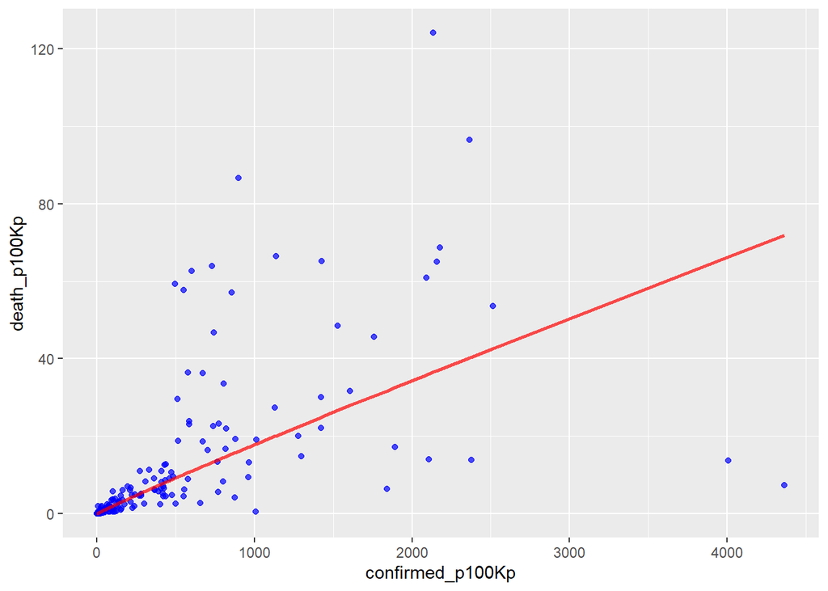

```r
ggplot( data = df, aes( x = confirmed_p100Kp, y = death_p100Kp) ) +
  geom_point(color='blue',alpha=0.7)+
  #geom_smooth( method = lm , color = 'green', alpha=0.7)+
  geom_line(aes( x = confirmed_p100Kp, y = reg1_y_pred),size=1,color="red",alpha=0.7)
```

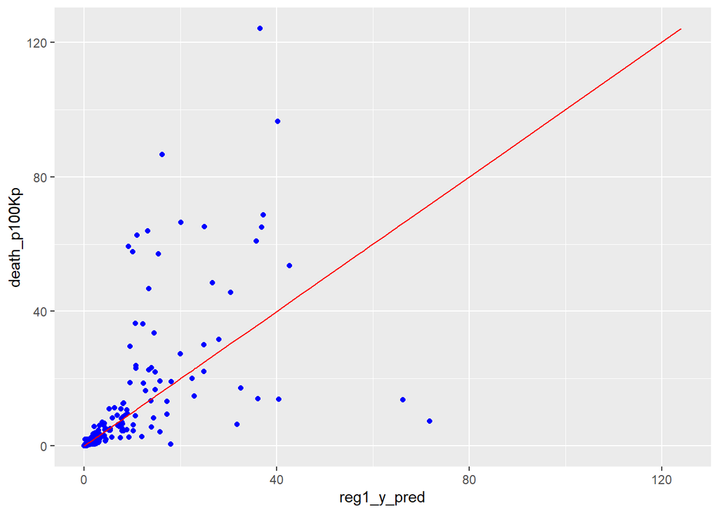

```r
#
ggplot( data = df, aes( x = reg1_y_pred, y = death_p100Kp ) ) +
  geom_point( color='blue')+
  geom_line(aes( x = death_p100Kp, y = death_p100Kp ),color="red")
```

## Appendix

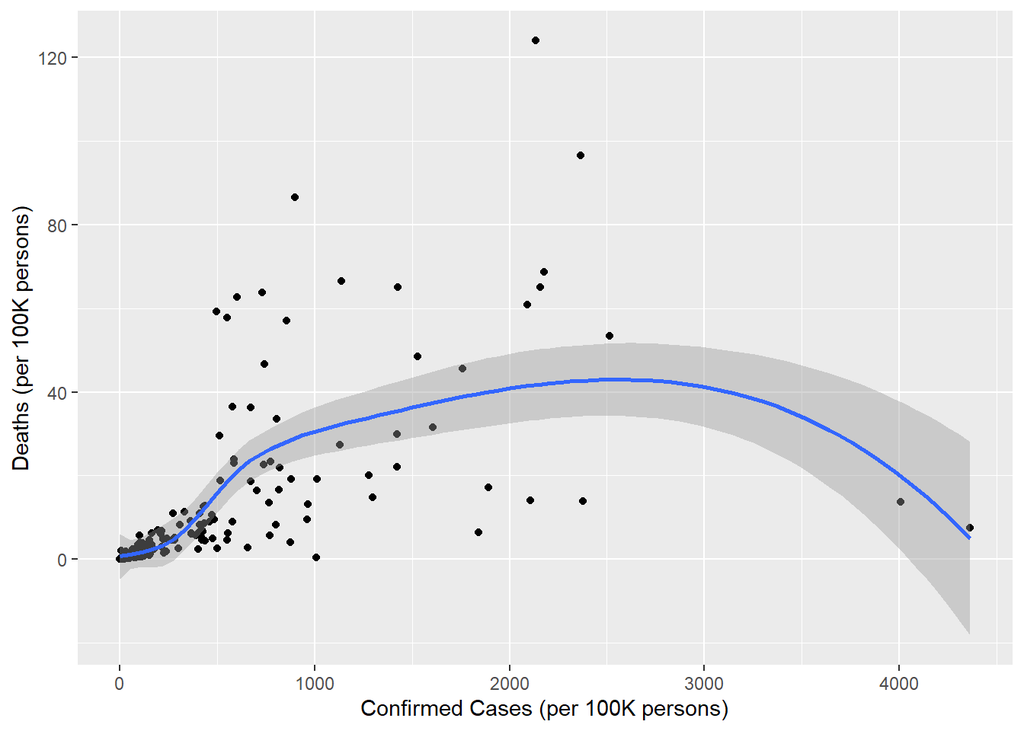

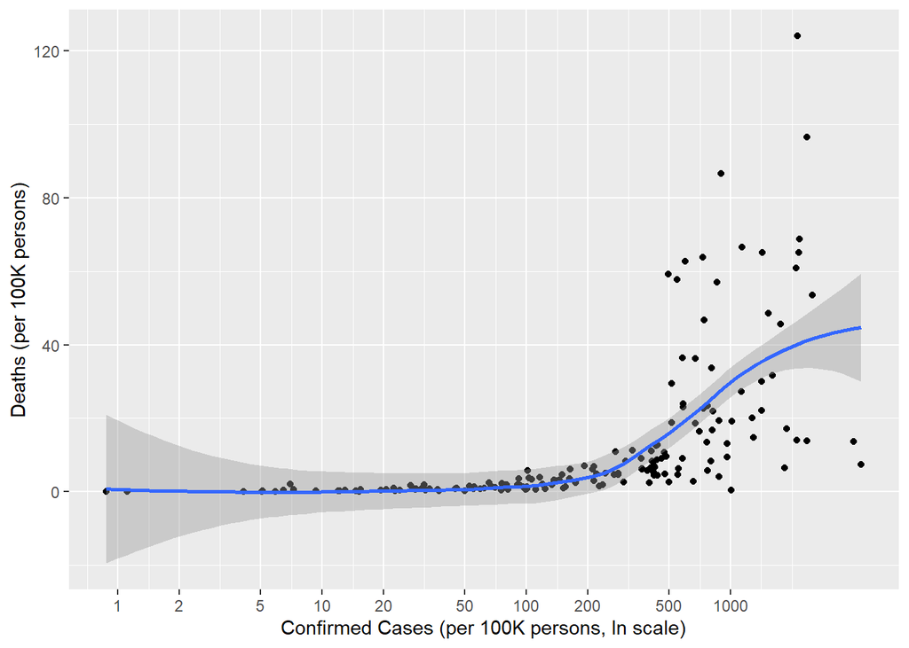

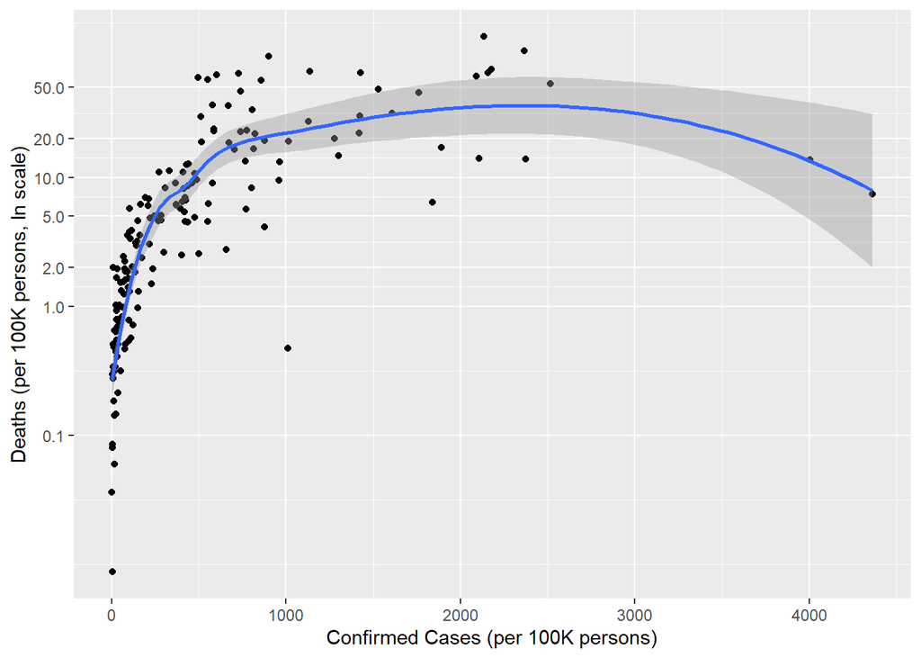

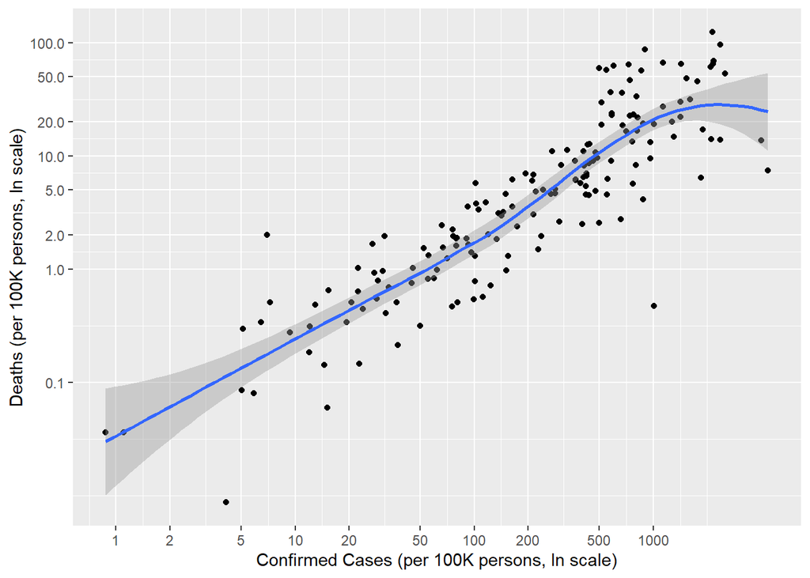

[output not shown]

[output not shown]

[output not shown]

[output not shown]

[output not shown]